# Predict Outcome of NBA Game

kyle wurtz

2017-04-12

## Overview

This file will take the output of models built elsewhere to predict the outcome of a given NBA game.

## Setup

### Load Packages

```r
require(tidyverse)
require(magrittr)
require(scales)
require(ggthemes)
require(stringr)
require(lubridate)
```

## Work

To predict the outcome of an NBA game, I’ll leverage three high-level components: a pre-game prediction, an in-game prediction, and a credibility metric to assign weight to the two predictions. To begin with, my models will be *extremely* simple. This is deliberate, as I’ll be taking an agile-ish approach to this work: I’ll start with laughably simple models and iterate frequently with small updates.

### Pre-Game Prediction

#### Version 1

The pre-game prediction model will require the most work of the three components. To begin with, the “model” will only be a function of the two teams’ winning percentages. This model will predict the probability that the home team wins the game, so the pre-game prediction model in version 1 will be: 0.5 + Home Team’s Winning % - Away Team’s Winning %. The winning percentages will be taken from the current season just prior to the start of the game.

##### Load Game Outcome Data

Data copied from Basketball Reference for the 2016-17 season through March: http://www.basketball-reference.com/leagues/NBA_2017_games-march.html.

```r
results_1617 = read_csv("Data/Input/Pre_Game_Model/Results_2017.csv")
month_abbrevs = tibble(
  abbrev = c("Jan", "Feb", "Mar", "Apr", "May", "Jun", "Jul", "Aug", "Sep", "Oct", "Nov", "Dec"),
  month_num_str = str_pad(1:12, 2, pad = "0")
)

results_1617 %<>%
  mutate(
    Home_Win = ifelse(Home_Score > Away_Score, 1, 0),
    Winning_Team = ifelse(Home_Win == 1, Home, Away),
    Losing_Team = ifelse(Home_Win == 1, Away, Home)
  ) %>%
  separate(
    Date,
    c("Day_of_Week", "Month", "Day_Of_Month", "Year")
  ) %>%
  left_join(
    month_abbrevs,
    by = c("Month" = "abbrev")
  ) %>%
  mutate(date = ymd(paste0(Year, month_num_str, Day_Of_Month))) %>%
  select(date, Away:Losing_Team)

teams = sort(unique(results_1617$Home))
```

##### Create Function to Get Records Through a Given Date

```r
records_through_dt = function(df, eval_date) {
  df %<>% filter(date <= eval_date)
  df %>%
    count(Winning_Team) %>%
    rename(team = Winning_Team,
           wins = n) %>%
    full_join(
      df %>%
        count(Losing_Team) %>%
        rename(team = Losing_Team,
               losses = n)
    ) %>%
    replace_na(list(
      wins = 0, losses = 0
    )) %>%
    mutate(win_perc = wins / (wins + losses))
}
# results_1617 %>% records_through_dt(ymd("20161025"))
```

##### Evaluate Model

```r
pre_game_pred = function(home_wp, away_wp) {
  home_wp = ifelse(is.na(home_wp), 0, home_wp)
  away_wp = ifelse(is.na(away_wp), 0, away_wp)
  pred = 0.5 + home_wp - away_wp
  pred = max(0, pred)
  pred = min(1, pred)
  return(pred)
}
pre_game_pred = Vectorize(pre_game_pred)

pred_pre_game = function(df, game_date) {
  records = df %>%
    records_through_dt(game_date - 1) %>%
    select(team, win_perc)

  results_1617 %>%
    filter(date == game_date) %>%
    left_join(
      records,
      by = c("Home" = "team")
    ) %>%
    rename(home_win_perc = win_perc) %>%
    left_join(
      records,
      by = c("Away" = "team")
    ) %>%
    rename(away_win_perc = win_perc) %>%
    mutate(home_pre_game_prob = pre_game_pred(home_win_perc, away_win_perc))
}

score_pre_game_model = function(df) {
  df %>%
    mutate(
      correct = ifelse(
        home_pre_game_prob == 0.5,
        "Too Close",
        ifelse(
          (Home_Win == 1 & home_pre_game_prob > 0.5) | (Home_Win == 0 & home_pre_game_prob < 0.5),
          "Yes",
          "No"
        )
      )
    )
}

eval_pre_game_model = function(df_scored) {
  df_scored %>%
    group_by(correct) %>%
    summarize(games = n()) %>%
    mutate(dist = games / sum(games))
}

pre_game_results = tibble(
  through_date = unique(results_1617$date),
  correct = NA,
  incorrect = NA,
  too_close = NA
)
for (i in 1:nrow(pre_game_results)) {
  dt = pre_game_results$through_date[i]
  temp = tibble(
    correct = c("Yes", "No", "Too Close")
  ) %>%
    left_join(
      results_1617 %>%
        pred_pre_game(dt) %>%
        score_pre_game_model() %>%
        eval_pre_game_model()
    )

  pre_game_results$correct[i] = temp$games[temp$correct == "Yes"]
  pre_game_results$incorrect[i] = temp$games[temp$correct == "No"]
  pre_game_results$too_close[i] = temp$games[temp$correct == "Too Close"]
}
```

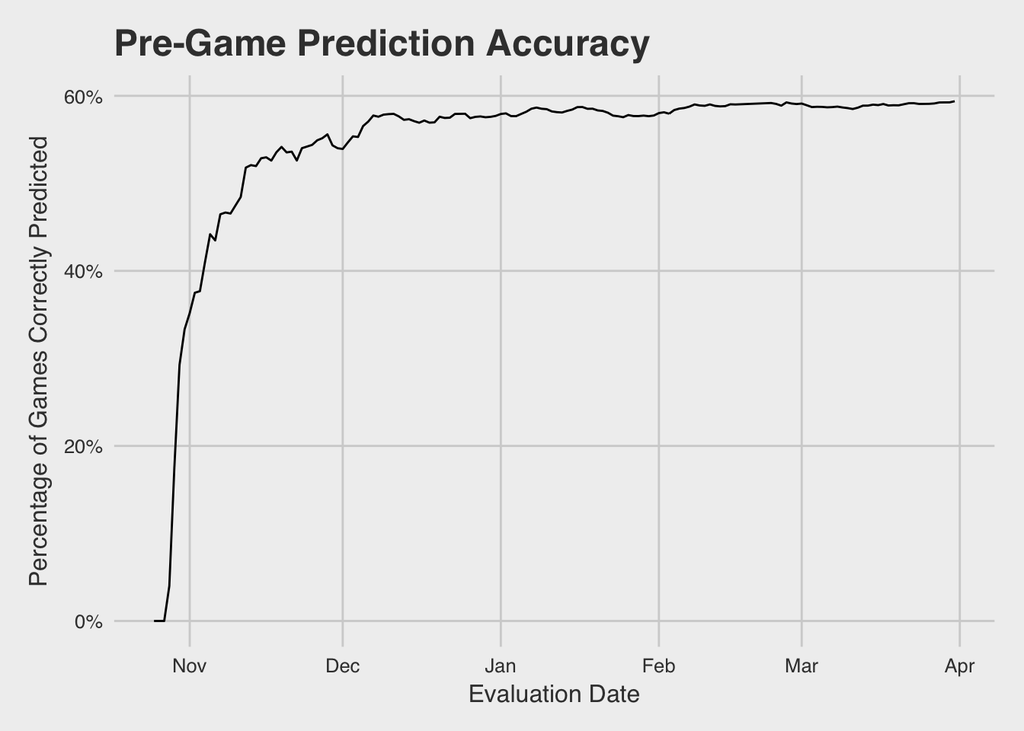

```r
pre_game_results %>%
  replace_na(list(
    correct = 0,
    incorrect = 0,
    too_close = 0
  )) %>%
  mutate(
    games = correct + incorrect + too_close,
    cum_games = cumsum(games),
    cum_correct = cumsum(correct),
    cum_incorrect = cumsum(incorrect),
    cum_tooclose = cumsum(too_close),
    perc_correct = cum_correct / cum_games
  ) %>%
  ggplot(., aes(x = through_date, y = perc_correct)) +
  geom_line() +
  theme_fivethirtyeight() +
  theme(axis.title = element_text()) +
  xlab("Evaluation Date") +
  ylab("Percentage of Games Correctly Predicted") +
  scale_y_continuous(labels = percent) +
  ggtitle("Pre-Game Prediction Accuracy")
```

```r
# results_1617 %>% pred_pre_game(ymd("20161025")) %>% score_pre_game_model()
# results_1617 %>% pred_pre_game(ymd("20161025")) %>% score_pre_game_model() %>% eval_pre_game_model()
```

### In-Game Prediction

#### Version 1

The in-game model in version 1 will be: (Home Team Score - Away Team Score + 20) / 40 with the probability floored at 0 and capped at 1. Effectively, this will provide a probability of winning of 0 if the home team is down by 20 points or more, a probability of winning of 1 if the home team is winning by 20 points or more, and a straight line of increasing probability between these two points.

##### Load Data from BigDataBall

This model requires only two inputs – the home team score and the away team score. For usage in real time, I’ll likely scrape the score from a website, but for evaluating this model I’ll use play-by-play data from BigDataBall.com.

```r
bdb = read_csv("/Users/kylewurtz/Dropbox/R/NBA Analysis/BigDataBall Data/CSV Files/16-17-pbp-data/[10-25-2016]-[03-20-2017]-combined-stats.csv")
# View(bdb)
bdb %<>%
  mutate(game_id = gsub("=", "", game_id),
         game_id = gsub('"', "", game_id),
         game_id = as.numeric(game_id))
```

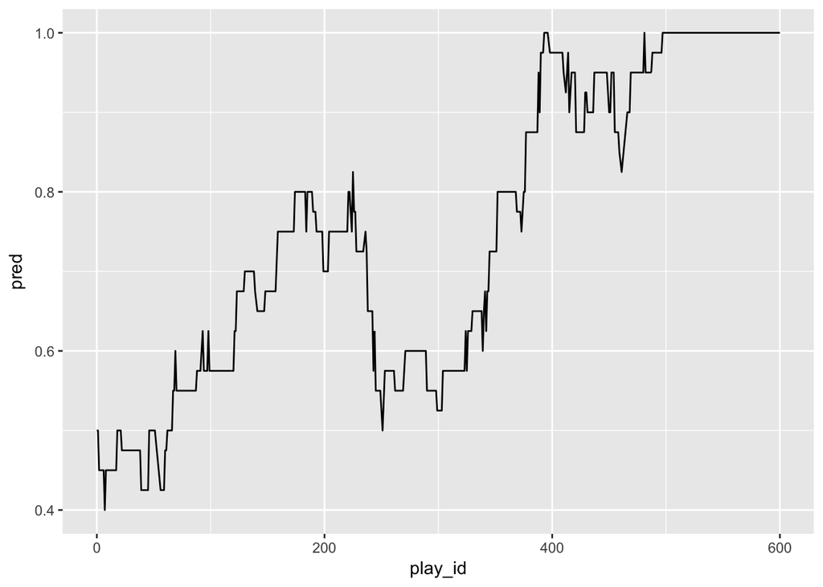

```r
gm = bdb %>% filter(game_id == 21600001)

score_in_game_model = function(home_score, away_score) {
  pred = ((home_score - away_score) + 20) / 40
  pred = min(pred, 1)
  pred = max(pred, 0)
  return(pred)
}
score_in_game_model = Vectorize(score_in_game_model)

gm %>%
  mutate(
    pred = score_in_game_model(home_score, away_score)
  ) %>%
  select(play_id, home_score, away_score, pred) %>%
  ggplot(., aes(x = play_id, y = pred)) +
  geom_line()
```

### Credibility

#### Version 1

The credibility metric in version 1 will simply be: Minutes into the Game / 48, capped at 1 (for overtime games).